# Risk Factor Analysis

## Outcome Variable

**Outcome Variable:** ever_stunted

## Predictor Variables

**Intervention Variable:** fhtcm

**Adjustment Set:**

unadjusted

## Stratifying Variables

The analysis was stratified on these variable(s):

- agecat
- studyid

The following strata were considered:

- agecat: 12 months, studyid: ki1000304b-SAS-CompFeed
- agecat: 12 months, studyid: ki1000304b-SAS-FoodSuppl
- agecat: 12 months, studyid: ki1101329-Keneba
- agecat: 12 months, studyid: ki1119695-PROBIT
- agecat: 12 months, studyid: ki1135781-COHORTS
- agecat: 18 months, studyid: ki1000304b-SAS-CompFeed
- agecat: 18 months, studyid: ki1000304b-SAS-FoodSuppl
- agecat: 18 months, studyid: ki1101329-Keneba
- agecat: 18 months, studyid: ki1119695-PROBIT
- agecat: 18 months, studyid: ki1135781-COHORTS
- agecat: 24 months, studyid: ki1000304b-SAS-CompFeed
- agecat: 24 months, studyid: ki1000304b-SAS-FoodSuppl
- agecat: 24 months, studyid: ki1101329-Keneba
- agecat: 24 months, studyid: ki1119695-PROBIT
- agecat: 24 months, studyid: ki1135781-COHORTS
- agecat: 3 months, studyid: ki1000304b-SAS-CompFeed
- agecat: 3 months, studyid: ki1101329-Keneba
- agecat: 3 months, studyid: ki1119695-PROBIT
- agecat: 3 months, studyid: ki1135781-COHORTS
- agecat: 6 months, studyid: ki1000304b-SAS-CompFeed
- agecat: 6 months, studyid: ki1000304b-SAS-FoodSuppl
- agecat: 6 months, studyid: ki1101329-Keneba
- agecat: 6 months, studyid: ki1119695-PROBIT

## Methods Detail

# Results Detail

## Results Plots

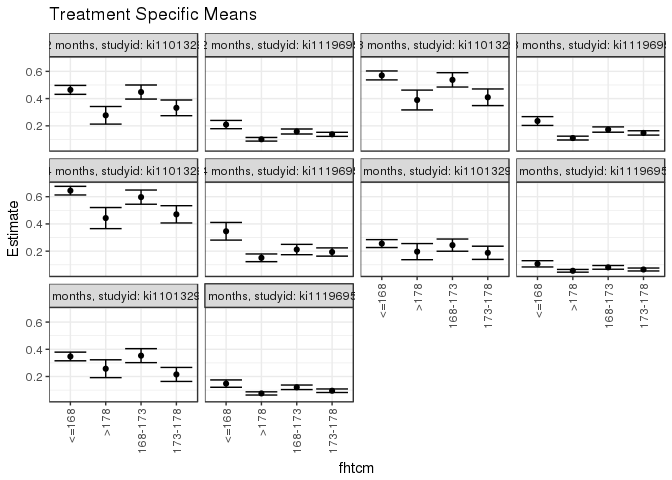

[figure not shown]

[figure not shown]

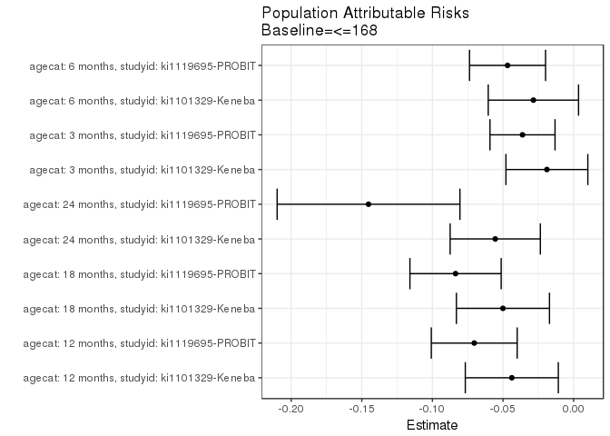

## Data Summary

| agecat | studyid | A | n | nA | nAY0 | nAY1 |
| --- | --- | --- | --- | --- | --- | --- |
| 12 months | ki1000304b-SAS-CompFeed | <=168 | 600 | 386 | 138 | 248 |
| 12 months | ki1000304b-SAS-CompFeed | >178 | 600 | 16 | 12 | 4 |
| 12 months | ki1000304b-SAS-CompFeed | 168-173 | 600 | 136 | 64 | 72 |
| 12 months | ki1000304b-SAS-CompFeed | 173-178 | 600 | 62 | 32 | 30 |
| 12 months | ki1000304b-SAS-FoodSuppl | <=168 | 97 | 84 | 12 | 72 |
| 12 months | ki1000304b-SAS-FoodSuppl | >178 | 97 | 1 | 0 | 1 |
| 12 months | ki1000304b-SAS-FoodSuppl | 168-173 | 97 | 8 | 1 | 7 |
| 12 months | ki1000304b-SAS-FoodSuppl | 173-178 | 97 | 4 | 1 | 3 |
| 12 months | ki1101329-Keneba | <=168 | 1687 | 890 | 477 | 413 |
| 12 months | ki1101329-Keneba | >178 | 1687 | 184 | 133 | 51 |
| 12 months | ki1101329-Keneba | 168-173 | 1687 | 357 | 197 | 160 |
| 12 months | ki1101329-Keneba | 173-178 | 1687 | 256 | 171 | 85 |
| 12 months | ki1119695-PROBIT | <=168 | 6226 | 688 | 544 | 144 |
| 12 months | ki1119695-PROBIT | >178 | 6226 | 1978 | 1778 | 200 |
| 12 months | ki1119695-PROBIT | 168-173 | 6226 | 1516 | 1276 | 240 |
| 12 months | ki1119695-PROBIT | 173-178 | 6226 | 2044 | 1763 | 281 |
| 12 months | ki1135781-COHORTS | <=168 | 208 | 194 | 39 | 155 |
| 12 months | ki1135781-COHORTS | >178 | 208 | 0 | 0 | 0 |
| 12 months | ki1135781-COHORTS | 168-173 | 208 | 7 | 2 | 5 |
| 12 months | ki1135781-COHORTS | 173-178 | 208 | 7 | 1 | 6 |
| 18 months | ki1000304b-SAS-CompFeed | <=168 | 580 | 371 | 77 | 294 |
| 18 months | ki1000304b-SAS-CompFeed | >178 | 580 | 17 | 13 | 4 |
| 18 months | ki1000304b-SAS-CompFeed | 168-173 | 580 | 129 | 42 | 87 |
| 18 months | ki1000304b-SAS-CompFeed | 173-178 | 580 | 63 | 24 | 39 |
| 18 months | ki1000304b-SAS-FoodSuppl | <=168 | 92 | 81 | 9 | 72 |
| 18 months | ki1000304b-SAS-FoodSuppl | >178 | 92 | 1 | 0 | 1 |
| 18 months | ki1000304b-SAS-FoodSuppl | 168-173 | 92 | 7 | 0 | 7 |
| 18 months | ki1000304b-SAS-FoodSuppl | 173-178 | 92 | 3 | 0 | 3 |
| 18 months | ki1101329-Keneba | <=168 | 1644 | 877 | 377 | 500 |
| 18 months | ki1101329-Keneba | >178 | 1644 | 172 | 105 | 67 |

[output cut: 70 more lines]

## Results Table

### Parameter: TSM

| agecat | studyid | intervention_level | baseline_level | estimate | ci_lower | ci_upper |
| --- | --- | --- | --- | --- | --- | --- |
| 12 months | ki1101329-Keneba | <=168 | NA | 0.4640449 | 0.4312712 | 0.4968187 |
| 12 months | ki1101329-Keneba | >178 | NA | 0.2771739 | 0.2124804 | 0.3418675 |
| 12 months | ki1101329-Keneba | 168-173 | NA | 0.4481793 | 0.3965771 | 0.4997814 |
| 12 months | ki1101329-Keneba | 173-178 | NA | 0.3320313 | 0.2743248 | 0.3897377 |
| 12 months | ki1119695-PROBIT | <=168 | NA | 0.2093023 | 0.1789018 | 0.2397028 |
| 12 months | ki1119695-PROBIT | >178 | NA | 0.1011122 | 0.0878253 | 0.1143992 |
| 12 months | ki1119695-PROBIT | 168-173 | NA | 0.1583113 | 0.1399347 | 0.1766879 |
| 12 months | ki1119695-PROBIT | 173-178 | NA | 0.1374755 | 0.1225462 | 0.1524049 |
| 18 months | ki1101329-Keneba | <=168 | NA | 0.5701254 | 0.5373509 | 0.6029000 |
| 18 months | ki1101329-Keneba | >178 | NA | 0.3895349 | 0.3166362 | 0.4624336 |
| 18 months | ki1101329-Keneba | 168-173 | NA | 0.5375723 | 0.4850211 | 0.5901234 |
| 18 months | ki1101329-Keneba | 173-178 | NA | 0.4096386 | 0.3485387 | 0.4707384 |
| 18 months | ki1119695-PROBIT | <=168 | NA | 0.2352941 | 0.2030032 | 0.2675851 |
| 18 months | ki1119695-PROBIT | >178 | NA | 0.1100478 | 0.0959041 | 0.1241916 |
| 18 months | ki1119695-PROBIT | 168-173 | NA | 0.1726272 | 0.1532001 | 0.1920543 |
| 18 months | ki1119695-PROBIT | 173-178 | NA | 0.1477858 | 0.1320006 | 0.1635710 |
| 24 months | ki1101329-Keneba | <=168 | NA | 0.6445714 | 0.6128472 | 0.6762956 |
| 24 months | ki1101329-Keneba | >178 | NA | 0.4430380 | 0.3655583 | 0.5205176 |
| 24 months | ki1101329-Keneba | 168-173 | NA | 0.5970588 | 0.5449066 | 0.6492110 |
| 24 months | ki1101329-Keneba | 173-178 | NA | 0.4705882 | 0.4071557 | 0.5340207 |
| 24 months | ki1119695-PROBIT | <=168 | NA | 0.3461538 | 0.2814840 | 0.4108237 |
| 24 months | ki1119695-PROBIT | >178 | NA | 0.1512195 | 0.1228974 | 0.1795416 |
| 24 months | ki1119695-PROBIT | 168-173 | NA | 0.2120536 | 0.1741925 | 0.2499147 |
| 24 months | ki1119695-PROBIT | 173-178 | NA | 0.1938931 | 0.1636088 | 0.2241774 |
| 3 months | ki1101329-Keneba | <=168 | NA | 0.2557339 | 0.2267685 | 0.2846994 |
| 3 months | ki1101329-Keneba | >178 | NA | 0.1965318 | 0.1372996 | 0.2557640 |
| 3 months | ki1101329-Keneba | 168-173 | NA | 0.2443182 | 0.1994172 | 0.2892192 |
| 3 months | ki1101329-Keneba | 173-178 | NA | 0.1880000 | 0.1395530 | 0.2364470 |
| 3 months | ki1119695-PROBIT | <=168 | NA | 0.1069364 | 0.0839096 | 0.1299632 |
| 3 months | ki1119695-PROBIT | >178 | NA | 0.0558350 | 0.0457413 | 0.0659287 |
| 3 months | ki1119695-PROBIT | 168-173 | NA | 0.0809743 | 0.0672547 | 0.0946939 |
| 3 months | ki1119695-PROBIT | 173-178 | NA | 0.0653659 | 0.0546654 | 0.0760663 |
| 6 months | ki1101329-Keneba | <=168 | NA | 0.3473193 | 0.3154514 | 0.3791873 |
| 6 months | ki1101329-Keneba | >178 | NA | 0.2573099 | 0.1917683 | 0.3228516 |
| 6 months | ki1101329-Keneba | 168-173 | NA | 0.3532934 | 0.3020154 | 0.4045714 |
| 6 months | ki1101329-Keneba | 173-178 | NA | 0.2154472 | 0.1640550 | 0.2668393 |
| 6 months | ki1119695-PROBIT | <=168 | NA | 0.1479821 | 0.1210729 | 0.1748912 |
| 6 months | ki1119695-PROBIT | >178 | NA | 0.0758048 | 0.0639829 | 0.0876266 |
| 6 months | ki1119695-PROBIT | 168-173 | NA | 0.1207598 | 0.1041238 | 0.1373959 |
| 6 months | ki1119695-PROBIT | 173-178 | NA | 0.0955478 | 0.0826599 | 0.1084356 |

### Parameter: E(Y)

| agecat | studyid | intervention_level | baseline_level | estimate | ci_lower | ci_upper |
| --- | --- | --- | --- | --- | --- | --- |
| 12 months | ki1101329-Keneba | NA | NA | 0.4202727 | 0.4170385 | 0.4235068 |
| 12 months | ki1119695-PROBIT | NA | NA | 0.1389335 | 0.1381119 | 0.1397551 |
| 18 months | ki1101329-Keneba | NA | NA | 0.5200730 | 0.5166433 | 0.5235026 |
| 18 months | ki1119695-PROBIT | NA | NA | 0.1516835 | 0.1507179 | 0.1526491 |
| 24 months | ki1101329-Keneba | NA | NA | 0.5890751 | 0.5853384 | 0.5928118 |
| 24 months | ki1119695-PROBIT | NA | NA | 0.2009346 | 0.1984424 | 0.2034267 |
| 3 months | ki1101329-Keneba | NA | NA | 0.2367942 | 0.2354856 | 0.2381027 |
| 3 months | ki1119695-PROBIT | NA | NA | 0.0707313 | 0.0703387 | 0.0711239 |
| 6 months | ki1101329-Keneba | NA | NA | 0.3188316 | 0.3162845 | 0.3213787 |
| 6 months | ki1119695-PROBIT | NA | NA | 0.1011866 | 0.1005967 | 0.1017764 |

### Parameter: RR

[output not shown]

### Parameter: PAR

| agecat | studyid | intervention_level | baseline_level | estimate | ci_lower | ci_upper |
| --- | --- | --- | --- | --- | --- | --- |
| 12 months | ki1101329-Keneba | <=168 | NA | -0.0437723 | -0.0767052 | -0.0108393 |
| 12 months | ki1119695-PROBIT | <=168 | NA | -0.0703688 | -0.1007804 | -0.0399572 |
| 18 months | ki1101329-Keneba | <=168 | NA | -0.0500524 | -0.0830059 | -0.0170989 |
| 18 months | ki1119695-PROBIT | <=168 | NA | -0.0836106 | -0.1159160 | -0.0513052 |
| 24 months | ki1101329-Keneba | <=168 | NA | -0.0554963 | -0.0874398 | -0.0235528 |
| 24 months | ki1119695-PROBIT | <=168 | NA | -0.1452193 | -0.2099371 | -0.0805015 |
| 3 months | ki1101329-Keneba | <=168 | NA | -0.0189398 | -0.0479347 | 0.0100552 |
| 3 months | ki1119695-PROBIT | <=168 | NA | -0.0362051 | -0.0592353 | -0.0131749 |
| 6 months | ki1101329-Keneba | <=168 | NA | -0.0284878 | -0.0604574 | 0.0034818 |
| 6 months | ki1119695-PROBIT | <=168 | NA | -0.0467955 | -0.0737111 | -0.0198799 |

### Parameter: PAF

[output not shown]